# Clustering

Johanna Mehler

2024-03-27

# 1 Preparation

```
## here() starts at /Users/Jo/OneDrive/1_Hertie Studies/Thesis/Hertie-Thesis-Mehler
##
```

# 2 PAM clustering

## 2.1 Finding the best number of clusters

### 2.1.1 Silhouette Method

The silhouette coefficient is a measure of how similar an object is to its own cluster (cohesion) compared to other clusters (separation). The silhouette score ranges from -1 to +1, where a high value indicates that the object is well matched to its own cluster and poorly matched to neighboring clusters.

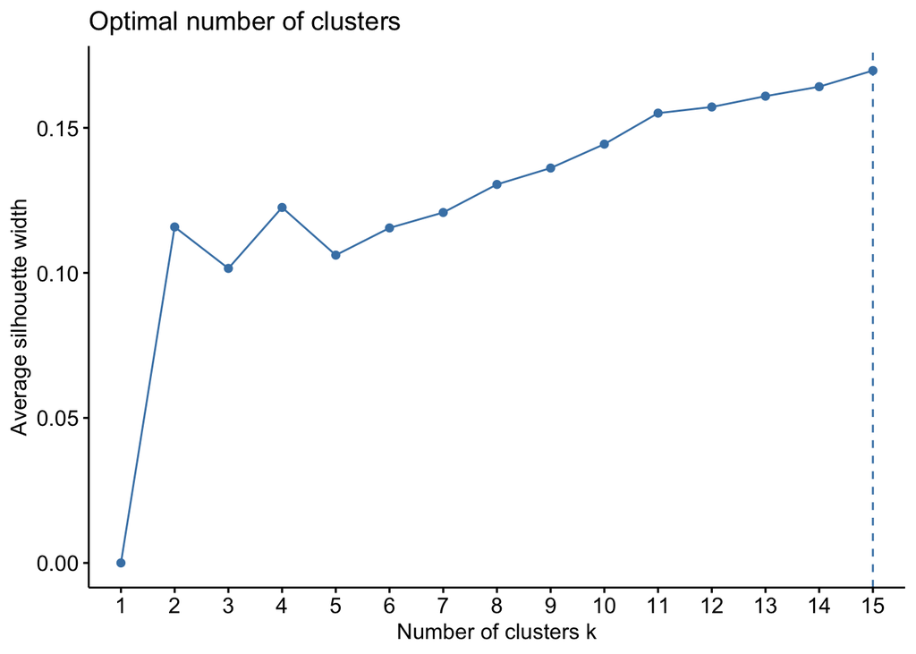

### 2.1.2 Elbow Method

The elbow method involves plotting the total within-cluster sum of squares (WSS) against the number of clusters, k, and looking for a ‘knee’ in the plot where the rate of decrease sharply changes. This ‘elbow’ typically indicates a good number of clusters to use.

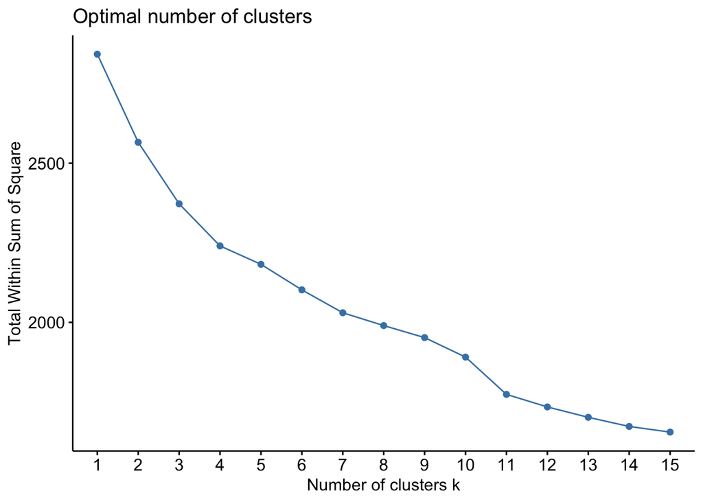

4 or 6 seems to be good

# 3 PAM Method with 4 clusters

## 3.1 Best Representative of Each Cluster

```
## Medoid 896 represents a cluster with 302 observations. Items:
## [1] "content.attack" "scope.person"
##
## Medoid 676 represents a cluster with 343 observations. Items:
## [1] "scope.people"
##
## Medoid 1029 represents a cluster with 189 observations. Items:
## [1] "other.nonsense"
##
## Medoid 851 represents a cluster with 198 observations. Items:
## [1] "content.incitement" "scope.people"
```

## 3.2 Cluster Summary Statistics

### 3.2.1 Item count by Cluster

```
## # A tibble: 45 × 5
##    column                   `1`   `2`   `3`   `4`
##    <chr>                  <dbl> <dbl> <dbl> <dbl>
##  1 content.attack           227    52     0    41
##  2 content.causingharm        7    13     1     6
##  3 content.dehumanization    55    67     0    22
##  4 content.form              19    27     0    15
##  5 content.harassment        11    16     0     9
##  6 content.hateful           58    91     0    27
##  7 content.incitement         7     0     0   198
##  8 content.incivility        51    34     0    12
##  9 content.law                6     5     0    11
## 10 content.misinformation    17    14     0    14
## # ℹ 35 more rows
```

### 3.2.2 Cluster Statistics

```
##   cluster observations.Freq share.Freq mean_amount_items variance_amount_items
## 1       1               302  0.2926357          4.761589             3.8765264
## 2       2               343  0.3323643          5.341108             4.1493871
## 3       3               189  0.1831395          4.730159             0.4108409
## 4       4               198  0.1918605          8.111111             4.5155104
```

### 3.2.3 Mean number of items and variance within each cluster

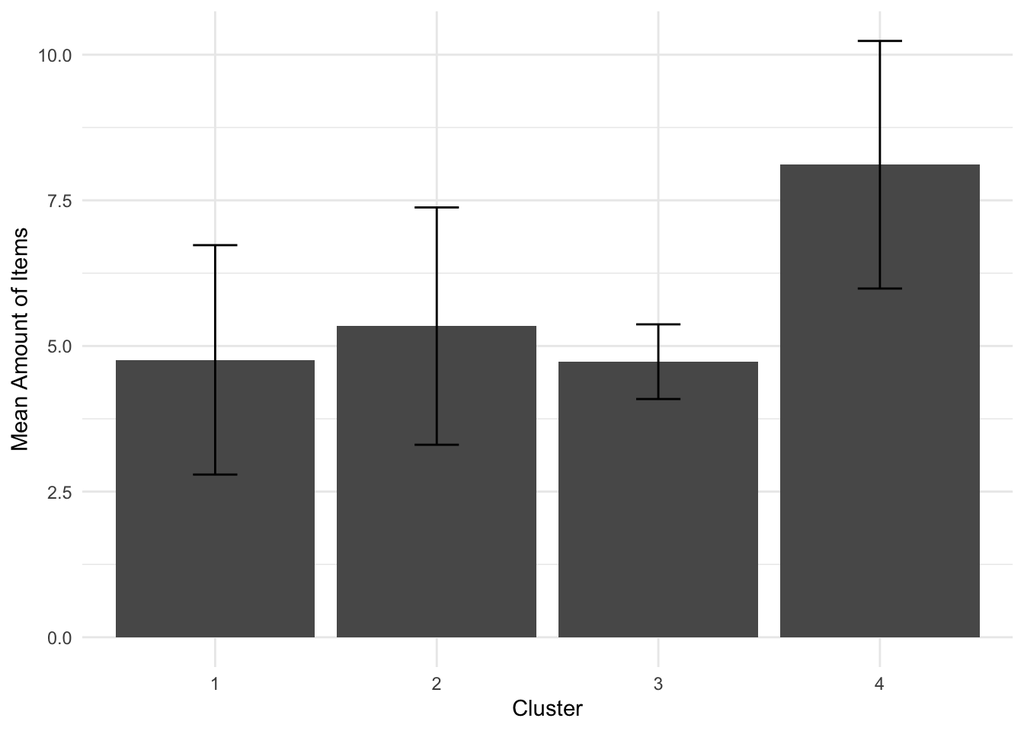

### 3.2.4 Most important items in each cluster

*Cluster 1*

```
## # A tibble: 8 × 3
##   cluster item                    mean
##     <int> <chr>                  <dbl>
## 1       1 content.attack         0.752
## 2       1 scope.person           0.722
## 3       1 content.hateful        0.192
## 4       1 content.dehumanization 0.182
## 5       1 target.race            0.172
## 6       1 content.incivility     0.169
## 7       1 scope.people           0.152
## 8       1 content.offensive      0.149
```

Main components for cluster 1 are “attack (75%) against a person (72%)”

*Cluster 2*

```
## # A tibble: 8 × 3
##   cluster item                    mean
##     <int> <chr>                  <dbl>
## 1       2 scope.people           0.566
## 2       2 content.hateful        0.265
## 3       2 target.race            0.201
## 4       2 content.dehumanization 0.195
## 5       2 content.offensive      0.175
## 6       2 scope.person           0.155
## 7       2 content.attack         0.152
## 8       2 target.religion        0.149
```

Main components for cluster 2 are “offensive (17%), hateful (27%), dehumanization (20%), content against a group of people (57%) because of their race (20%)”

*Cluster 3*

```
## # A tibble: 8 × 3
##   cluster item                   mean
##     <int> <chr>                 <dbl>
## 1       3 other.nonsense      1
## 2       3 other.existence     0.259
## 3       3 other.importance    0.196
## 4       3 other.subjective    0.164
## 5       3 other.consequences  0.0741
## 6       3 content.opinion     0.0159
## 7       3 other.example       0.0106
## 8       3 content.causingharm 0.00529
```

Cluster 3 is about nonsense (100%) and other features from the section “other”, mostly deniying existence, importance, or any objective characteristics of hate speech.

*Cluster 4*

```
## # A tibble: 8 × 3
##   cluster item                    mean
##     <int> <chr>                  <dbl>
## 1       4 content.incitement     1
## 2       4 scope.people           0.616
## 3       4 scope.person           0.318
## 4       4 content.attack         0.207
## 5       4 target.race            0.187
## 6       4 target.religion        0.157
## 7       4 content.hateful        0.136
## 8       4 content.dehumanization 0.111
```

-> Would be interesting to look at some text examples of these definitions compared to the other clusters.

### 3.2.5 Visualize Cluster

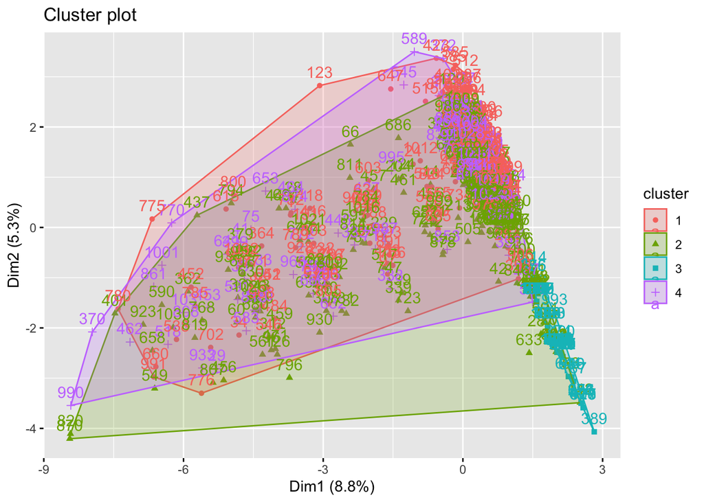

## 3.3 PAM Method with 6 clusters

### 3.3.1 Best Representative and Size of each Cluster

```
## Medoid 896 represents a cluster with 218 observations. Items:
## [1] "content.attack" "scope.person"   "cluster"
##
## Medoid 676 represents a cluster with 343 observations. Items:
## [1] "scope.people"
##
## Medoid 1029 represents a cluster with 140 observations. Items:
## [1] "other.nonsense"
##
## Medoid 851 represents a cluster with 198 observations. Items:
## [1] "content.incitement" "scope.people"
##
## Medoid 972 represents a cluster with 49 observations. Items:
## [1] "other.existence" "other.nonsense"
##
## Medoid 910 represents a cluster with 84 observations. Items:
## [1] "content.attack" "cluster"
```

### 3.3.2 Visualize

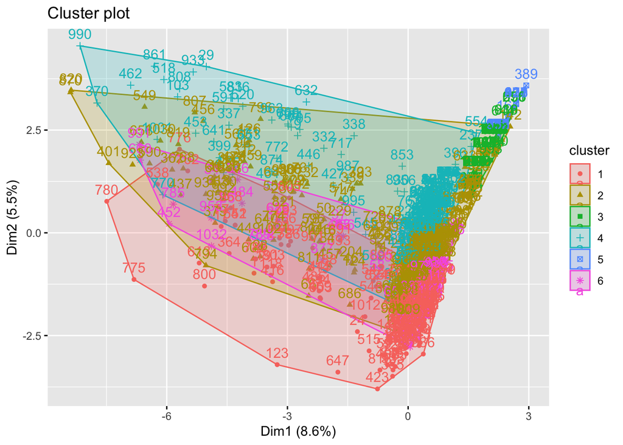

## 3.4 PAM Method with 8 clusters

### 3.4.1 Best Representative and Size of each Cluster

```
## Medoid 896 represents a cluster with 218 observations. Items:
## [1] "content.attack" "scope.person"   "cluster"
##
## Medoid 676 represents a cluster with 343 observations. Items:
## [1] "scope.people"
##
## Medoid 1029 represents a cluster with 103 observations. Items:
## [1] "other.nonsense"
##
## Medoid 851 represents a cluster with 122 observations. Items:
## [1] "content.incitement" "scope.people"
##
## Medoid 972 represents a cluster with 49 observations. Items:
## [1] "other.existence" "other.nonsense"
##
## Medoid 974 represents a cluster with 76 observations. Items:
## [1] "content.incitement"
##
## Medoid 910 represents a cluster with 84 observations. Items:
## [1] "content.attack" "cluster"
##
## Medoid 957 represents a cluster with 37 observations. Items:
## [1] "other.importance" "other.nonsense"
```

### 3.4.2 Visualize

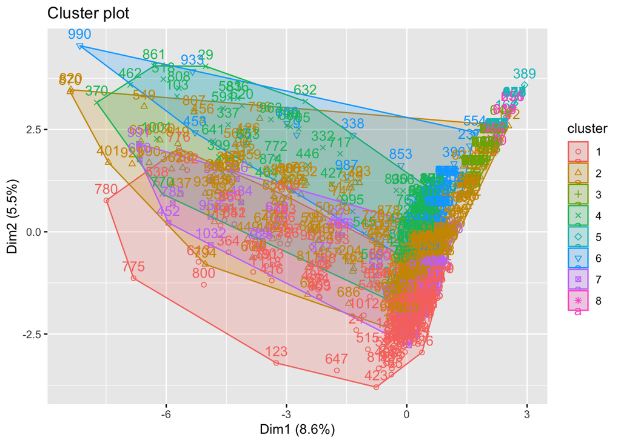

## 3.5 PAM Method with 2 clusters

### 3.5.1 Best Representative of Each Cluster

```
## Medoid 65 represents a cluster with 407 observations. Items:
## [1] "content.attack" "scope.person"   "cluster"
##
## Medoid 1029 represents a cluster with 625 observations. Items:
## [1] "other.nonsense"
```

### 3.5.2 Visualize

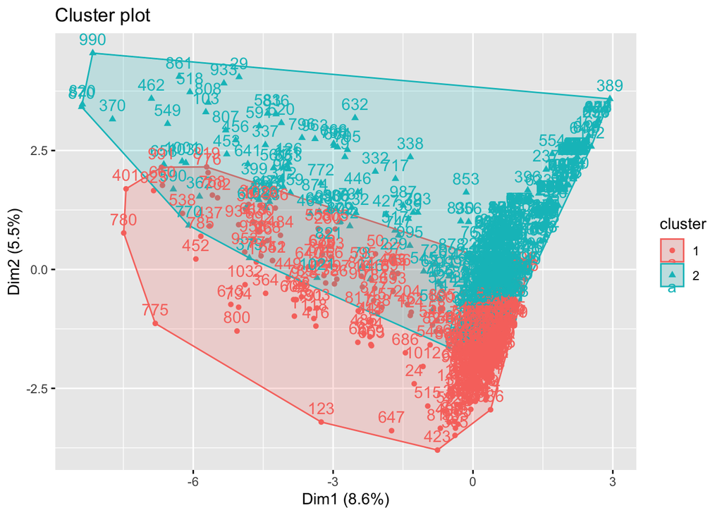